# US Name

Estimate tso2 as a function of credit_constraint and others variables

# Description

- New baseline table

## Variables

### Target

tso2

### Features

- credit_constraint
- period
- tso2_mandate_c
- supply_all_credit

## Complementary information

# Metadata

- Key: 174_Pollution_and_Credit_Constraint
- Epic: Models
- US: Baseline tables
- Task tag: #data-analysis
- Analytics reports:

# Input Cloud Storage

## Table/file

**Name**

- fin_dep_pollution_baseline_industry

**Github**

- https://github.com/thomaspernet/pollution_credit_constraint/blob/master/01_data_preprocessing/02_transform_tables/00_credit_constraint_industry.md

# Load tables

Since we load the data as a Pandas DataFrame, we want to pass the `dtypes`. We load the schema from Glue to guess the types

|  | Name | Type | Comment |
| --- | --- | --- | --- |
| 0 | year | string | year from 2001 to 2007 |
| 1 | period | varchar(5) | False if year before 2005 included, True if year 2006 and 2007 |
| 2 | province_en | string |  |
| 3 | cityen | string |  |
| 4 | geocode4_corr | string |  |
| ... | ... | ... | ... |
| 79 | dominated_sales_for_i | map<double,boolean> | map with information on foreign dominated industry knowing percentile .5, .75, .9, .95 of sales |
| 80 | dominated_capital_for_i | map<double,boolean> | map with information on foreign dominated industry knowing percentile .5, .75, .9, .95 of capital |
| 81 | fe_c_i | bigint | City industry fixed effect |
| 82 | fe_t_i | bigint | year industry fixed effect |
| 83 | fe_c_t | bigint | city industry fixed effect |

84 rows × 3 columns

## Schema Latex table

To rename a variable, please use the following template:

```
{
    'old':'XX',
    'new':'XX_1'
    }
```

if you need to pass a latex format with `\`, you need to duplicate it for instance, `\text` becomes `\text:

```
{
    'old':'working\_capital\_i',
    'new':'\\text{working capital}_i'
    }
```

Then add it to the key `to_rename`

```
 Hlavac, Marek (2018). stargazer: Well-Formatted Regression and Summary Statistics Tables.
 R package version 5.2.2. https://CRAN.R-project.org/package=stargazer
```

## Table 1:Baseline regression

$$ \begin{aligned} SO2_{ckt} = \alpha \text{credit constraint}_{k} \times Post_{t} \times \text{Reduction Mandate}_{c} + \mu_{ct} + \gamma_{kt} + \delta_{ck} + \epsilon_{ckt} \end{aligned} $$

and

$$ \begin{aligned} SO2_{ckt} = \alpha \text{credit supply}_{p} \times Post_{t} \times \text{Reduction Mandate}_{c} + \gamma_{kt} + \delta_{ck} + \epsilon_{ckt} \end{aligned} $$

**External**

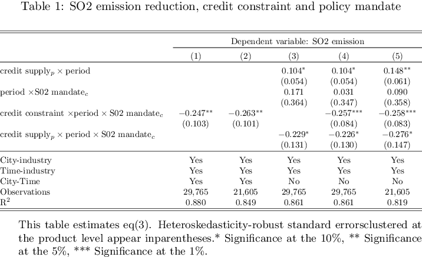

## Table 2:Parallel trend

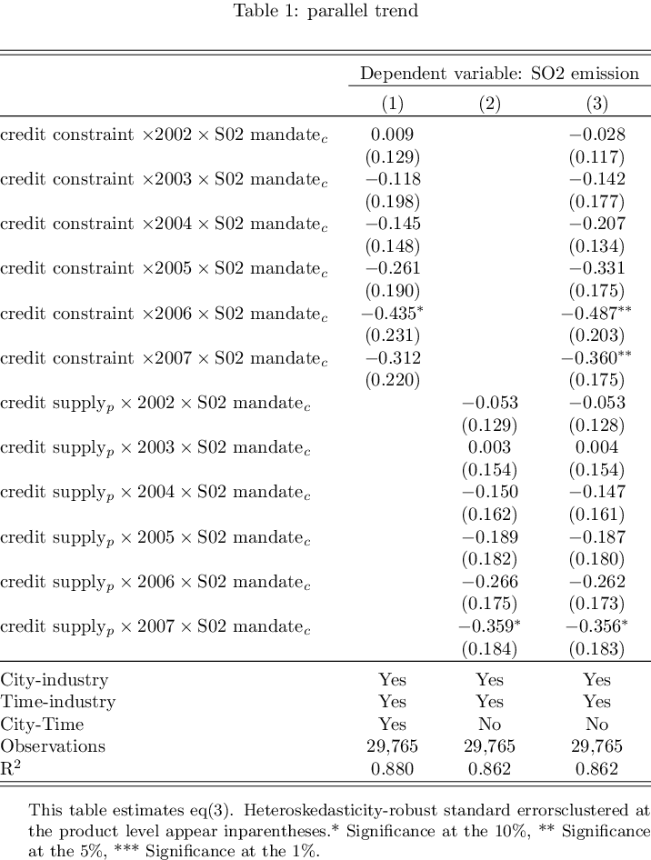

## Table 3: heterogeneous effect

City ownership are available for the following variables:

- output
- capital
- employment
- sales

**How is it constructed**

- city ownership public vs private
  - Aggregate output by ownership and city
  - A given city will have SOE asset tangibility and PRIVATE asset tangibility [output, employment, capital and sales]
  - If asset tangibility SOE above Private then city is dominated by SOE

Notebook reference: https://github.com/thomaspernet/Financial_dependency_pollution/blob/master/01_data_preprocessing/02_transform_tables/07_dominated_city_ownership.md

Industrial are available for the following variables:

- output
- capital
- employment
- sales

**Industrial size effect**

- Change computation large vs small industry
  - Compute the median (percentile) within a city taking all firms
  - Compute the median (percentile) within a city-industry taking all firms within the industry
  - For instance, Shanghai has 3 sectors, compute the median for Shanghai, and 3 median for each sector

Notebook reference: https://github.com/thomaspernet/Financial_dependency_pollution/blob/master/01_data_preprocessing/02_transform_tables/08_dominated_industry_ownership.md

### Credit constraint

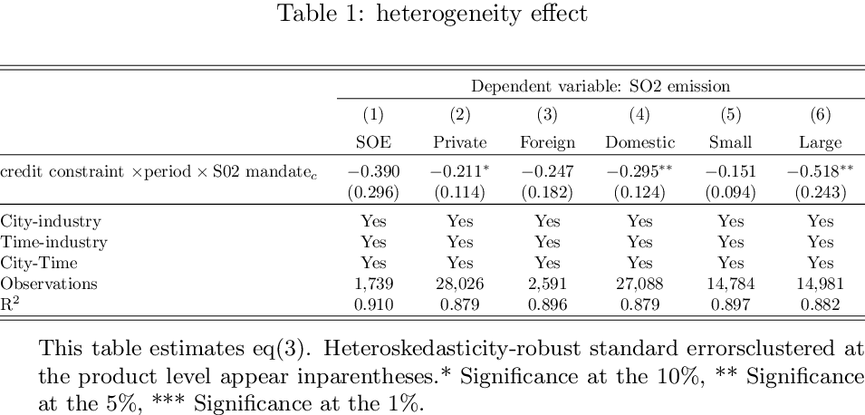

### Credit supply

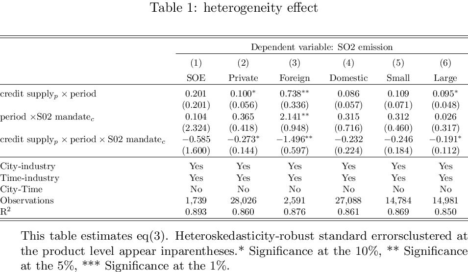

## Table 4: TCZ & SPZ policy

### Credit constraint

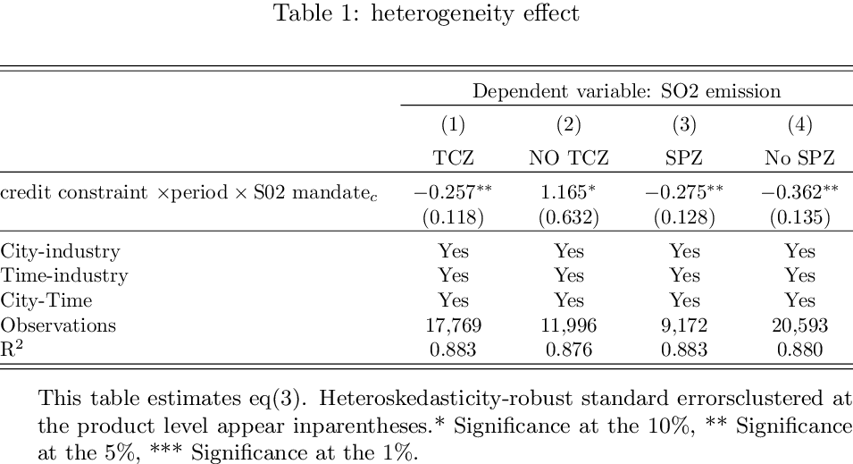

### Credit supply

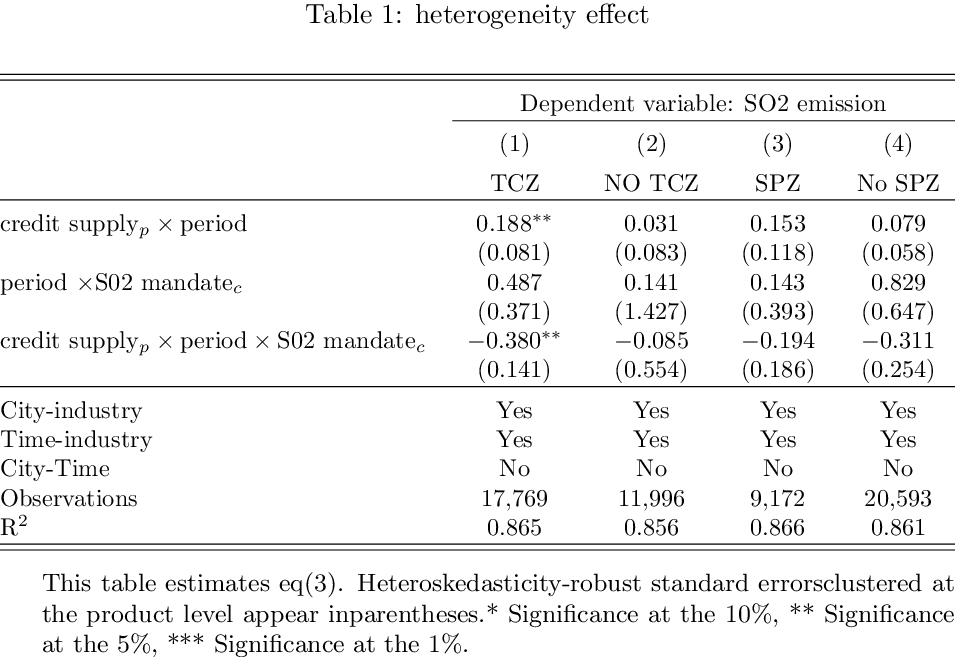

## Table 5: Internal finance

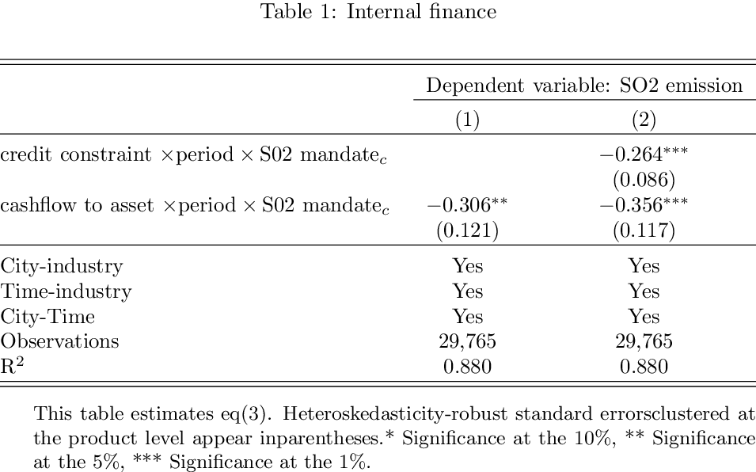

## Table 6: Relocation

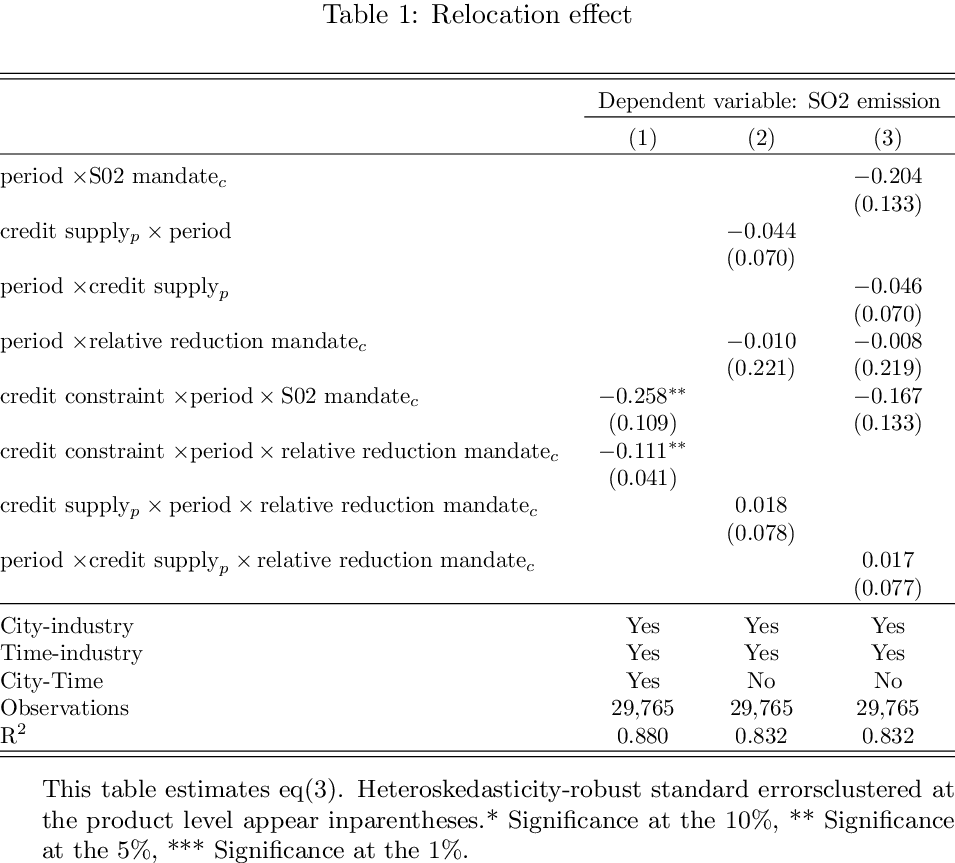